# Supervised Machine Learning Techniques Assignment I

```python
gbm_gridperf1 = gbm_grid1.get_grid(sort_by='residual_deviance')
gbm_gridperf1
```

```
      col_sample_rate  max_depth  min_rows  sample_rate  \
0                 0.5        2.0      20.0          0.8
1                 0.5        2.0      50.0          1.0
2                 0.5        2.0       5.0          0.8
3                 1.0        2.0       5.0          1.0
4                 0.5        5.0     100.0          1.0
5                 0.2        5.0       5.0          0.8
6                 1.0        5.0     100.0          1.0
7                 1.0        5.0       5.0          1.0
8                 1.0       50.0     100.0          1.0
9                 0.2       10.0      50.0          0.8
10                1.0       50.0     100.0          0.8
11                1.0        5.0      20.0          1.0
12                1.0       20.0     100.0          1.0
13                1.0       50.0      50.0          0.8
```

[output cut: 32 more lines]

The best model after tuning

```python
best_gbm1 = gbm_gridperf1.models[0]
best_gbm1
```

```
Model Details
=============
H2OGradientBoostingEstimator :  Gradient Boosting Machine
Model Key:  gbm_grid_tune_model_5


Model Summary:
```

|  |  | number_of_trees | number_of_internal_trees | model_size_in_bytes | min_depth | max_depth | mean_depth | min_leaves | max_leaves | mean_leaves |
| --- | --- | --- | --- | --- | --- | --- | --- | --- | --- | --- |
| 0 |  | 1078.0 | 1078.0 | 121908.0 | 2.0 | 2.0 | 2.0 | 3.0 | 4.0 | 3.852505 |

```
ModelMetricsRegression: gbm
** Reported on train data. **

MSE: 0.1406133627041228
RMSE: 0.3749844832844725
MAE: 0.28752617625519633
RMSLE: 0.2621630483905631
Mean Residual Deviance: 0.1406133627041228

ModelMetricsRegression: gbm
** Reported on cross-validation data. **

MSE: 0.14588524302247496
RMSE: 0.38194926760300896
MAE: 0.2928863572813485
RMSLE: 0.2677016285467321
Mean Residual Deviance: 0.14588524302247496

Cross-Validation Metrics Summary:
```

|  |  | mean | sd | cv_1_valid | cv_2_valid | cv_3_valid | cv_4_valid | cv_5_valid | cv_6_valid | cv_7_valid | cv_8_valid | cv_9_valid | cv_10_valid |
| --- | --- | --- | --- | --- | --- | --- | --- | --- | --- | --- | --- | --- | --- |
| 0 | mae | 0.293008 | 0.004074 | 0.294566 | 0.293631 | 0.293820 | 0.286895 | 0.297220 | 0.285438 | 0.298161 | 0.293087 | 0.295381 | 0.291878 |
| 1 | mean_residual_deviance | 0.146019 | 0.003698 | 0.147220 | 0.144137 | 0.146527 | 0.141018 | 0.150000 | 0.139825 | 0.150943 | 0.148244 | 0.148307 | 0.143969 |
| 2 | mse | 0.146019 | 0.003698 | 0.147220 | 0.144137 | 0.146527 | 0.141018 | 0.150000 | 0.139825 | 0.150943 | 0.148244 | 0.148307 | 0.143969 |
| 3 | r2 | 0.041566 | 0.017611 | 0.071000 | 0.055832 | 0.040679 | 0.005575 | 0.033104 | 0.052273 | 0.028482 | 0.038943 | 0.040478 | 0.049293 |
| 4 | residual_deviance | 0.146019 | 0.003698 | 0.147220 | 0.144137 | 0.146527 | 0.141018 | 0.150000 | 0.139825 | 0.150943 | 0.148244 | 0.148307 | 0.143969 |
| 5 | rmse | 0.382097 | 0.004851 | 0.383693 | 0.379653 | 0.382789 | 0.375524 | 0.387299 | 0.373932 | 0.388514 | 0.385024 | 0.385106 | 0.379432 |
| 6 | rmsle | 0.267795 | 0.002861 | 0.267037 | 0.266354 | 0.268282 | 0.265819 | 0.271115 | 0.262295 | 0.272197 | 0.268931 | 0.269522 | 0.266393 |

```
Scoring History:
```

|  |  | timestamp | duration | number_of_trees | training_rmse | training_mae | training_deviance |
| --- | --- | --- | --- | --- | --- | --- | --- |
| 0 |  | 2022-07-26 14:20:29 | 5 min 11.750 sec | 0.0 | 0.390312 | 0.304688 | 0.152344 |
| 1 |  | 2022-07-26 14:20:29 | 5 min 11.766 sec | 10.0 | 0.386319 | 0.301332 | 0.149242 |
| 2 |  | 2022-07-26 14:20:29 | 5 min 11.829 sec | 20.0 | 0.383969 | 0.298665 | 0.147432 |
| 3 |  | 2022-07-26 14:20:29 | 5 min 11.844 sec | 30.0 | 0.382330 | 0.296842 | 0.146176 |
| 4 |  | 2022-07-26 14:20:29 | 5 min 11.860 sec | 40.0 | 0.381141 | 0.295049 | 0.145268 |
| 5 |  | 2022-07-26 14:20:29 | 5 min 11.875 sec | 50.0 | 0.380247 | 0.293979 | 0.144588 |
| 6 |  | 2022-07-26 14:20:29 | 5 min 11.891 sec | 60.0 | 0.379516 | 0.293211 | 0.144033 |
| 7 |  | 2022-07-26 14:20:29 | 5 min 11.907 sec | 70.0 | 0.378928 | 0.292354 | 0.143587 |
| 8 |  | 2022-07-26 14:20:29 | 5 min 11.922 sec | 80.0 | 0.378446 | 0.291845 | 0.143221 |
| 9 |  | 2022-07-26 14:20:29 | 5 min 11.938 sec | 90.0 | 0.378029 | 0.291380 | 0.142906 |
| 10 |  | 2022-07-26 14:20:29 | 5 min 11.954 sec | 100.0 | 0.377662 | 0.291016 | 0.142628 |
| 11 |  | 2022-07-26 14:20:29 | 5 min 11.969 sec | 110.0 | 0.377349 | 0.290573 | 0.142392 |
| 12 |  | 2022-07-26 14:20:29 | 5 min 11.985 sec | 120.0 | 0.377079 | 0.290199 | 0.142189 |
| 13 |  | 2022-07-26 14:20:30 | 5 min 12.000 sec | 130.0 | 0.376838 | 0.289979 | 0.142007 |
| 14 |  | 2022-07-26 14:20:30 | 5 min 12.016 sec | 140.0 | 0.376631 | 0.289587 | 0.141851 |
| 15 |  | 2022-07-26 14:20:30 | 5 min 12.032 sec | 150.0 | 0.376446 | 0.289355 | 0.141712 |
| 16 |  | 2022-07-26 14:20:30 | 5 min 12.047 sec | 160.0 | 0.376289 | 0.289112 | 0.141594 |
| 17 |  | 2022-07-26 14:20:30 | 5 min 12.063 sec | 170.0 | 0.376165 | 0.288968 | 0.141500 |
| 18 |  | 2022-07-26 14:20:30 | 5 min 12.078 sec | 180.0 | 0.376042 | 0.288850 | 0.141408 |
| 19 |  | 2022-07-26 14:20:30 | 5 min 12.125 sec | 190.0 | 0.375925 | 0.288706 | 0.141320 |

```
See the whole table with table.as_data_frame()

Variable Importances:
```

|  | variable | relative_importance | scaled_importance | percentage |
| --- | --- | --- | --- | --- |
| 0 | MB007 | 878.583069 | 1.000000 | 0.254799 |
| 1 | MB005 | 240.508514 | 0.273746 | 0.069750 |
| 2 | AP003 | 220.502457 | 0.250975 | 0.063948 |
| 3 | TD013 | 213.931839 | 0.243496 | 0.062043 |
| 4 | TD005 | 191.323196 | 0.217763 | 0.055486 |
| 5 | CR015 | 175.192886 | 0.199404 | 0.050808 |
| 6 | TD009 | 146.692307 | 0.166965 | 0.042542 |
| 7 | TD014 | 123.858154 | 0.140975 | 0.035920 |
| 8 | TD002 | 118.357292 | 0.134714 | 0.034325 |
| 9 | AP002 | 118.067810 | 0.134384 | 0.034241 |
| 10 | PA031 | 113.869263 | 0.129606 | 0.033023 |
| 11 | AP008 | 105.341209 | 0.119899 | 0.030550 |
| 12 | PA029 | 91.725258 | 0.104401 | 0.026601 |
| 13 | TD001 | 82.734596 | 0.094168 | 0.023994 |
| 14 | TD023 | 73.499863 | 0.083657 | 0.021316 |
| 15 | TD024 | 68.572289 | 0.078049 | 0.019887 |
| 16 | CR009 | 62.412094 | 0.071037 | 0.018100 |
| 17 | CR019 | 48.955029 | 0.055720 | 0.014197 |
| 18 | PA028 | 46.364632 | 0.052772 | 0.013446 |
| 19 | TD010 | 40.307289 | 0.045878 | 0.011690 |

```
See the whole table with table.as_data_frame()
```

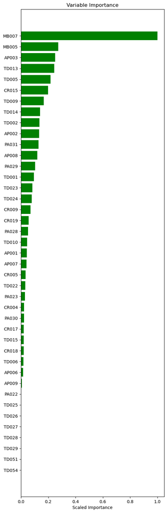

```python
VarImp(best_gbm1)
```

```python
createGains(best_gbm1)
```

```
gbm prediction progress: |███████████████████████████████████████████████████████| (done) 100%
```

| decile | count | actual | non_actual | cum_count | cum_actual | cum_non_actual | percent_cum_actual | percent_cum_non_actual | if_random | lift | K_S | gain |
| --- | --- | --- | --- | --- | --- | --- | --- | --- | --- | --- | --- | --- |
| 0 | 240 | 83 | 157 | 240 | 83 | 157 | 0.17 | 0.08 | 49.0 | 1.69 | 9.0 | 34.58 |
| 1 | 240 | 69 | 171 | 480 | 152 | 328 | 0.31 | 0.17 | 98.0 | 1.55 | 14.0 | 31.67 |
| 2 | 240 | 64 | 176 | 720 | 216 | 504 | 0.44 | 0.26 | 147.0 | 1.47 | 18.0 | 30.00 |
| 3 | 240 | 60 | 180 | 960 | 276 | 684 | 0.56 | 0.36 | 196.0 | 1.41 | 20.0 | 28.75 |
| 4 | 240 | 46 | 194 | 1200 | 322 | 878 | 0.66 | 0.46 | 245.0 | 1.31 | 20.0 | 26.83 |
| 5 | 240 | 39 | 201 | 1440 | 361 | 1079 | 0.74 | 0.56 | 294.0 | 1.23 | 18.0 | 25.07 |
| 6 | 240 | 40 | 200 | 1680 | 401 | 1279 | 0.82 | 0.67 | 343.0 | 1.17 | 15.0 | 23.87 |
| 7 | 240 | 43 | 197 | 1920 | 444 | 1476 | 0.91 | 0.77 | 392.0 | 1.13 | 14.0 | 23.12 |
| 8 | 240 | 32 | 208 | 2160 | 476 | 1684 | 0.97 | 0.88 | 441.0 | 1.08 | 9.0 | 22.04 |
| 9 | 240 | 14 | 226 | 2400 | 490 | 1910 | 1.00 | 1.00 | 490.0 | 1.00 | 0.0 | 20.42 |

```
gbm prediction progress: |███████████████████████████████████████████████████████| (done) 100%

   * ROC curve: The ROC curve plots the true positive rate vs. the false rositive sate

	  * The area under the curve (AUC): A value between 0.5 (random) and 1.0 (perfect), measuring the prediction accuracy

   * Recall (R) = The number of true positives / (the number of true positives + the number of false negatives)
```

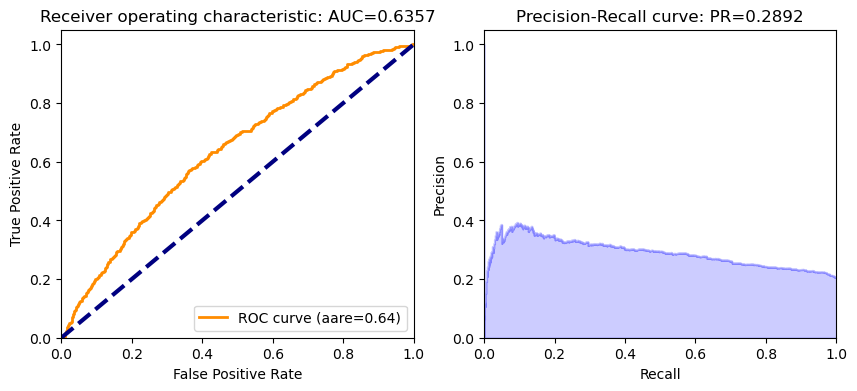

```python
ROC_AUC(best_gbm1,test_hex,'loan_default')
```

Conclusion:

- The tuned model has improved performance
- The lift score increased from 1.63 to 1.69.
- The AUC score increased from 0.62 to 0.64.

#### model with entire dataset

- use the tuned hyperparameters

```python
# entire dataset
train_hex = h2o.H2OFrame(train)
test_hex = h2o.H2OFrame(test)
```

```
Parse progress: |████████████████████████████████████████████████████████████████| (done) 100%
Parse progress: |████████████████████████████████████████████████████████████████| (done) 100%
```

```python
from h2o.estimators.gbm import H2OGradientBoostingEstimator
gbm_v2 = H2OGradientBoostingEstimator(
        model_id = 'gbm_v2',
        max_depth = 2,
        min_rows = 20,
        ntrees = 1078,
        col_sample_rate = 0.5,
        sample_rate = 0.8,
        nfolds = 10,
        seed=1234)
gbm_v2.train(predictors,target,training_frame=train_hex)
```

```
gbm Model Build progress: |██████████████████████████████████████████████████████| (done) 100%
Model Details
=============
H2OGradientBoostingEstimator :  Gradient Boosting Machine
Model Key:  gbm_v2


Model Summary:
```

|  |  | number_of_trees | number_of_internal_trees | model_size_in_bytes | min_depth | max_depth | mean_depth | min_leaves | max_leaves | mean_leaves |
| --- | --- | --- | --- | --- | --- | --- | --- | --- | --- | --- |
| 0 |  | 1078.0 | 1078.0 | 112483.0 | 0.0 | 2.0 | 1.408163 | 1.0 | 4.0 | 3.044527 |

```
ModelMetricsRegression: gbm
** Reported on train data. **

MSE: 0.14172846947465562
RMSE: 0.37646841763241656
MAE: 0.28749816936929024
RMSLE: 0.26388636733985354
Mean Residual Deviance: 0.14172846947465562

ModelMetricsRegression: gbm
** Reported on cross-validation data. **

MSE: 0.1476427600557886
RMSE: 0.3842431002058314
MAE: 0.2935330494335379
RMSLE: 0.26988082121934936
Mean Residual Deviance: 0.1476427600557886

Cross-Validation Metrics Summary:
```

|  |  | mean | sd | cv_1_valid | cv_2_valid | cv_3_valid | cv_4_valid | cv_5_valid | cv_6_valid | cv_7_valid | cv_8_valid | cv_9_valid | cv_10_valid |
| --- | --- | --- | --- | --- | --- | --- | --- | --- | --- | --- | --- | --- | --- |
| 0 | mae | 0.293538 | 0.002085 | 0.296830 | 0.291240 | 0.294050 | 0.292134 | 0.291791 | 0.292717 | 0.293949 | 0.292803 | 0.292435 | 0.297426 |
| 1 | mean_residual_deviance | 0.147644 | 0.001905 | 0.150911 | 0.147150 | 0.146420 | 0.147040 | 0.147351 | 0.146876 | 0.147412 | 0.147603 | 0.144751 | 0.150928 |
| 2 | mse | 0.147644 | 0.001905 | 0.150911 | 0.147150 | 0.146420 | 0.147040 | 0.147351 | 0.146876 | 0.147412 | 0.147603 | 0.144751 | 0.150928 |
| 3 | r2 | 0.052821 | 0.006651 | 0.053734 | 0.046083 | 0.051774 | 0.048951 | 0.051417 | 0.053378 | 0.048152 | 0.060867 | 0.067252 | 0.046598 |
| 4 | residual_deviance | 0.147644 | 0.001905 | 0.150911 | 0.147150 | 0.146420 | 0.147040 | 0.147351 | 0.146876 | 0.147412 | 0.147603 | 0.144751 | 0.150928 |
| 5 | rmse | 0.384238 | 0.002474 | 0.388472 | 0.383601 | 0.382649 | 0.383459 | 0.383863 | 0.383244 | 0.383943 | 0.384192 | 0.380461 | 0.388495 |
| 6 | rmsle | 0.269878 | 0.001498 | 0.272052 | 0.269590 | 0.269477 | 0.269518 | 0.269404 | 0.269340 | 0.270040 | 0.269359 | 0.267327 | 0.272669 |

```
Scoring History:
```

|  |  | timestamp | duration | number_of_trees | training_rmse | training_mae | training_deviance |
| --- | --- | --- | --- | --- | --- | --- | --- |
| 0 |  | 2022-07-26 17:46:30 | 2 min 12.545 sec | 0.0 | 0.394820 | 0.311765 | 0.155883 |
| 1 |  | 2022-07-26 17:46:30 | 2 min 12.716 sec | 1.0 | 0.393896 | 0.310909 | 0.155154 |
| 2 |  | 2022-07-26 17:46:31 | 2 min 12.756 sec | 2.0 | 0.393239 | 0.310309 | 0.154637 |
| 3 |  | 2022-07-26 17:46:31 | 2 min 12.795 sec | 3.0 | 0.392659 | 0.309811 | 0.154181 |
| 4 |  | 2022-07-26 17:46:31 | 2 min 12.831 sec | 4.0 | 0.392151 | 0.309190 | 0.153782 |
| 5 |  | 2022-07-26 17:46:31 | 2 min 12.882 sec | 5.0 | 0.391547 | 0.308591 | 0.153309 |
| 6 |  | 2022-07-26 17:46:31 | 2 min 12.903 sec | 6.0 | 0.391038 | 0.308096 | 0.152911 |
| 7 |  | 2022-07-26 17:46:31 | 2 min 12.922 sec | 7.0 | 0.390598 | 0.307585 | 0.152567 |
| 8 |  | 2022-07-26 17:46:31 | 2 min 12.943 sec | 8.0 | 0.390279 | 0.307232 | 0.152318 |
| 9 |  | 2022-07-26 17:46:31 | 2 min 12.965 sec | 9.0 | 0.389939 | 0.306921 | 0.152053 |
| 10 |  | 2022-07-26 17:46:31 | 2 min 12.986 sec | 10.0 | 0.389649 | 0.306651 | 0.151826 |
| 11 |  | 2022-07-26 17:46:31 | 2 min 13.005 sec | 11.0 | 0.389395 | 0.306294 | 0.151628 |
| 12 |  | 2022-07-26 17:46:31 | 2 min 13.028 sec | 12.0 | 0.389134 | 0.306043 | 0.151425 |
| 13 |  | 2022-07-26 17:46:31 | 2 min 13.051 sec | 13.0 | 0.388828 | 0.305731 | 0.151187 |
| 14 |  | 2022-07-26 17:46:31 | 2 min 13.073 sec | 14.0 | 0.388578 | 0.305363 | 0.150993 |
| 15 |  | 2022-07-26 17:46:31 | 2 min 13.097 sec | 15.0 | 0.388360 | 0.305065 | 0.150824 |
| 16 |  | 2022-07-26 17:46:31 | 2 min 13.123 sec | 16.0 | 0.388147 | 0.304807 | 0.150658 |
| 17 |  | 2022-07-26 17:46:31 | 2 min 13.145 sec | 17.0 | 0.387911 | 0.304347 | 0.150475 |
| 18 |  | 2022-07-26 17:46:31 | 2 min 13.168 sec | 18.0 | 0.387686 | 0.304114 | 0.150301 |
| 19 |  | 2022-07-26 17:46:31 | 2 min 13.191 sec | 19.0 | 0.387499 | 0.303880 | 0.150156 |

```
See the whole table with table.as_data_frame()

Variable Importances:
```

|  | variable | relative_importance | scaled_importance | percentage |
| --- | --- | --- | --- | --- |
| 0 | MB007 | 670.328186 | 1.000000 | 0.159588 |
| 1 | TD013 | 522.613647 | 0.779638 | 0.124421 |
| 2 | AP003 | 495.961487 | 0.739879 | 0.118075 |
| 3 | TD009 | 355.083923 | 0.529717 | 0.084536 |
| 4 | AP005 | 254.309006 | 0.379380 | 0.060544 |
| 5 | MB005 | 216.338287 | 0.322735 | 0.051504 |
| 6 | CR015 | 209.545212 | 0.312601 | 0.049887 |
| 7 | TD005 | 163.441742 | 0.243823 | 0.038911 |
| 8 | PA028 | 159.362106 | 0.237737 | 0.037940 |
| 9 | TD014 | 120.659653 | 0.180001 | 0.028726 |
| 10 | TD001 | 98.392097 | 0.146782 | 0.023425 |
| 11 | PA031 | 83.153587 | 0.124049 | 0.019797 |
| 12 | CR009 | 62.995998 | 0.093978 | 0.014998 |
| 13 | PA023 | 61.106926 | 0.091160 | 0.014548 |
| 14 | AP002 | 58.441071 | 0.087183 | 0.013913 |
| 15 | PA029 | 57.814255 | 0.086248 | 0.013764 |
| 16 | AP007 | 53.298473 | 0.079511 | 0.012689 |
| 17 | PA030 | 50.996788 | 0.076077 | 0.012141 |
| 18 | TD024 | 49.658745 | 0.074081 | 0.011822 |
| 19 | PA022 | 47.418095 | 0.070739 | 0.011289 |

```
See the whole table with table.as_data_frame()
```

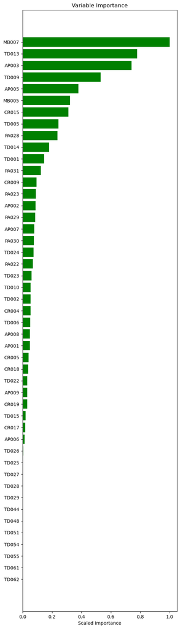

```python
VarImp(gbm_v2)
```

```python
createGains(gbm_v2)
```

```
gbm prediction progress: |███████████████████████████████████████████████████████| (done) 100%
```

| decile | count | actual | non_actual | cum_count | cum_actual | cum_non_actual | percent_cum_actual | percent_cum_non_actual | if_random | lift | K_S | gain |
| --- | --- | --- | --- | --- | --- | --- | --- | --- | --- | --- | --- | --- |
| 0 | 2400 | 873 | 1527 | 2400 | 873 | 1527 | 0.19 | 0.08 | 466.8 | 1.87 | 11.0 | 36.38 |
| 1 | 2400 | 705 | 1695 | 4800 | 1578 | 3222 | 0.34 | 0.17 | 933.6 | 1.69 | 17.0 | 32.88 |
| 2 | 2400 | 606 | 1794 | 7200 | 2184 | 5016 | 0.47 | 0.26 | 1400.4 | 1.56 | 21.0 | 30.33 |
| 3 | 2400 | 525 | 1875 | 9600 | 2709 | 6891 | 0.58 | 0.36 | 1867.2 | 1.45 | 22.0 | 28.22 |
| 4 | 2400 | 468 | 1932 | 12000 | 3177 | 8823 | 0.68 | 0.46 | 2334.0 | 1.36 | 22.0 | 26.48 |
| 5 | 2400 | 415 | 1985 | 14400 | 3592 | 10808 | 0.77 | 0.56 | 2800.8 | 1.28 | 21.0 | 24.94 |
| 6 | 2400 | 376 | 2024 | 16800 | 3968 | 12832 | 0.85 | 0.66 | 3267.6 | 1.21 | 19.0 | 23.62 |
| 7 | 2400 | 325 | 2075 | 19200 | 4293 | 14907 | 0.92 | 0.77 | 3734.4 | 1.15 | 15.0 | 22.36 |
| 8 | 2400 | 203 | 2197 | 21600 | 4496 | 17104 | 0.96 | 0.88 | 4201.2 | 1.07 | 8.0 | 20.81 |
| 9 | 2400 | 172 | 2228 | 24000 | 4668 | 19332 | 1.00 | 1.00 | 4668.0 | 1.00 | 0.0 | 19.45 |

The bank can choose to underwrite Segment 7 to 9 and avoid Segment 0 to 3.

```
gbm prediction progress: |███████████████████████████████████████████████████████| (done) 100%
```

```
   * ROC curve: The ROC curve plots the true positive rate vs. the false rositive sate

	  * The area under the curve (AUC): A value between 0.5 (random) and 1.0 (perfect), measuring the prediction accuracy

   * Recall (R) = The number of true positives / (the number of true positives + the number of false negatives)
```

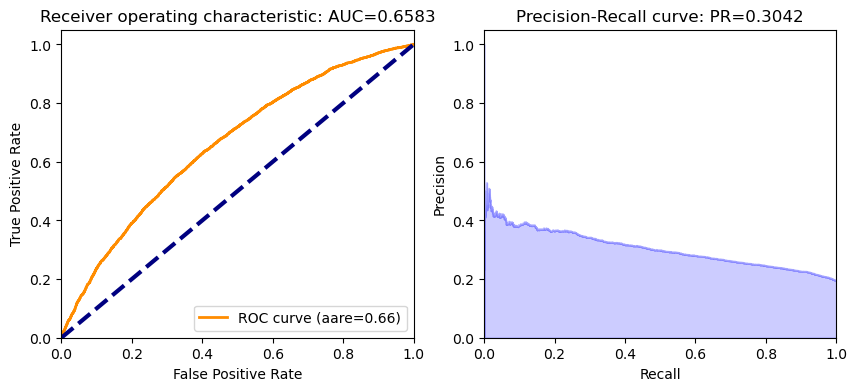

```python
ROC_AUC(gbm_v2,test_hex,'loan_default')
```

#### Conclusion:

- Train the model using entire training dataset, use all features and tuned hyperparameters
- The top three important features are MB007, TD013, AP003.
- The maximum lift is 1.87 and ROC curve has AUC score of 0.66.

## Modeling - Deep Learning

#### modeling best practices

- run with a small sample dataset
- adjust hyperparameters to achieve best performance
- use function of gain table, and ROC curve

```python
# create small sample dataset
train_smpl = train.sample(frac=0.1, random_state=1)
test_smpl = test.sample(frac=0.1, random_state=1)

train_hex = h2o.H2OFrame(train_smpl)
test_hex = h2o.H2OFrame(test_smpl)
predictors = CR_list + AP_list + MB_list + CR_list + PA_list +TD_list
target='loan_default'
```

```
Parse progress: |████████████████████████████████████████████████████████████████| (done) 100%
Parse progress: |████████████████████████████████████████████████████████████████| (done) 100%
```

```python
from h2o.estimators.deeplearning import H2ODeepLearningEstimator
dl_v1 = H2ODeepLearningEstimator(
    hidden=[64,64,64],
    input_dropout_ratio=0.2,
    sparse=True,
    epochs=10,
    nfolds = 10,
    seed = 1234)

dl_v1.train(
    x=predictors,
    y=target,
    training_frame=train_hex)
```

```
deeplearning Model Build progress: |
```

```
█████████████████████████████████████████████| (done) 100%
Model Details
=============
H2ODeepLearningEstimator :  Deep Learning
Model Key:  DeepLearning_model_python_1658859293893_1


Status of Neuron Layers: predicting loan_default, regression, gaussian distribution, Quadratic loss, 14,145 weights/biases, 176.7 KB, 60,039 training samples, mini-batch size 1
```

|  |  | layer | units | type | dropout | l1 | l2 | mean_rate | rate_rms | momentum | mean_weight | weight_rms | mean_bias | bias_rms |
| --- | --- | --- | --- | --- | --- | --- | --- | --- | --- | --- | --- | --- | --- | --- |
| 0 |  | 1 | 89 | Input | 20.0 |  |  |  |  |  |  |  |  |  |
| 1 |  | 2 | 64 | Rectifier | 0.0 | 0.0 | 0.0 | 0.140273 | 0.330422 | 0.0 | -0.005316 | 0.11689 | 0.477862 | 0.034978 |
| 2 |  | 3 | 64 | Rectifier | 0.0 | 0.0 | 0.0 | 0.009179 | 0.00584 | 0.0 | -0.016004 | 0.124291 | 0.942395 | 0.03976 |
| 3 |  | 4 | 64 | Rectifier | 0.0 | 0.0 | 0.0 | 0.027719 | 0.034933 | 0.0 | -0.02774 | 0.124677 | 0.871831 | 0.092992 |
| 4 |  | 5 | 1 | Linear |  | 0.0 | 0.0 | 0.000752 | 0.000271 | 0.0 | 0.008308 | 0.061007 | 0.156356 | 0.0 |

```
ModelMetricsRegression: deeplearning
** Reported on train data. **

MSE: 0.14425334934608355
RMSE: 0.3798069895961415
MAE: 0.2955613235253745
RMSLE: 0.26683444453416333
Mean Residual Deviance: 0.14425334934608355

ModelMetricsRegression: deeplearning
** Reported on cross-validation data. **

MSE: 0.14711951591613243
RMSE: 0.3835616194513372
MAE: 0.27744970449092754
RMSLE: 0.2663254382473038
Mean Residual Deviance: 0.14711951591613243

Cross-Validation Metrics Summary:
```

|  |  | mean | sd | cv_1_valid | cv_2_valid | cv_3_valid | cv_4_valid | cv_5_valid | cv_6_valid | cv_7_valid | cv_8_valid | cv_9_valid | cv_10_valid |
| --- | --- | --- | --- | --- | --- | --- | --- | --- | --- | --- | --- | --- | --- |
| 0 | mae | 0.277720 | 0.012923 | 0.292237 | 0.257918 | 0.278814 | 0.257243 | 0.274356 | 0.274298 | 0.289331 | 0.280032 | 0.295507 | 0.277460 |
| 1 | mean_residual_deviance | 0.147212 | 0.003984 | 0.150024 | 0.149819 | 0.148574 | 0.141201 | 0.151685 | 0.139997 | 0.149964 | 0.149023 | 0.147308 | 0.144522 |
| 2 | mse | 0.147212 | 0.003984 | 0.150024 | 0.149819 | 0.148574 | 0.141201 | 0.151685 | 0.139997 | 0.149964 | 0.149023 | 0.147308 | 0.144522 |
| 3 | r2 | 0.033810 | 0.015888 | 0.053310 | 0.018611 | 0.027280 | 0.004290 | 0.022244 | 0.051110 | 0.034784 | 0.033891 | 0.046941 | 0.045640 |
| 4 | residual_deviance | 0.147212 | 0.003984 | 0.150024 | 0.149819 | 0.148574 | 0.141201 | 0.151685 | 0.139997 | 0.149964 | 0.149023 | 0.147308 | 0.144522 |
| 5 | rmse | 0.383650 | 0.005221 | 0.387329 | 0.387065 | 0.385453 | 0.375767 | 0.389468 | 0.374162 | 0.387252 | 0.386035 | 0.383807 | 0.380160 |
| 6 | rmsle | 0.266406 | 0.003603 | 0.269205 | 0.266275 | 0.267174 | 0.261514 | 0.270252 | 0.259879 | 0.269790 | 0.267152 | 0.269153 | 0.263665 |

```
Scoring History:
```

|  |  | timestamp | duration | training_speed | epochs | iterations | samples | training_rmse | training_deviance | training_mae | training_r2 |
| --- | --- | --- | --- | --- | --- | --- | --- | --- | --- | --- | --- |
| 0 |  | 2022-07-26 14:35:48 | 0.000 sec | None | 0.000000 | 0 | 0.0 | NaN | NaN | NaN | NaN |
| 1 |  | 2022-07-26 14:35:49 | 9.531 sec | 42411 obs/sec | 1.067857 | 1 | 5980.0 | 0.385719 | 0.148780 | 0.263832 | 0.023396 |
| 2 |  | 2022-07-26 14:35:49 | 10.336 sec | 65616 obs/sec | 10.721250 | 10 | 60039.0 | 0.379807 | 0.144253 | 0.295561 | 0.053106 |

```
Variable Importances:
```

|  | variable | relative_importance | scaled_importance | percentage |
| --- | --- | --- | --- | --- |
| 0 | AP003 | 1.000000 | 1.000000 | 0.013989 |
| 1 | PA029 | 0.967351 | 0.967351 | 0.013533 |
| 2 | MB007.LETV | 0.960144 | 0.960144 | 0.013432 |
| 3 | MB007.OPPO | 0.959228 | 0.959228 | 0.013419 |
| 4 | TD002 | 0.957320 | 0.957320 | 0.013392 |
| 5 | PA028 | 0.950514 | 0.950514 | 0.013297 |
| 6 | AP006.h5 | 0.948786 | 0.948786 | 0.013273 |
| 7 | MB007.IPHONE4 | 0.935177 | 0.935177 | 0.013083 |
| 8 | MB007.CHANGHONG | 0.934395 | 0.934395 | 0.013072 |
| 9 | CR009 | 0.932805 | 0.932805 | 0.013049 |
| 10 | AP006.android | 0.921510 | 0.921510 | 0.012891 |
| 11 | AP008 | 0.915922 | 0.915922 | 0.012813 |
| 12 | AP002 | 0.914981 | 0.914981 | 0.012800 |
| 13 | TD024 | 0.912507 | 0.912507 | 0.012765 |
| 14 | MB005 | 0.910678 | 0.910678 | 0.012740 |
| 15 | MB007.DOOVL5PRO | 0.909735 | 0.909735 | 0.012727 |
| 16 | PA031 | 0.905136 | 0.905136 | 0.012662 |
| 17 | TD006 | 0.904721 | 0.904721 | 0.012657 |
| 18 | TD013 | 0.901169 | 0.901169 | 0.012607 |
| 19 | MB007.GIONEE | 0.895967 | 0.895967 | 0.012534 |

```
See the whole table with table.as_data_frame()
```

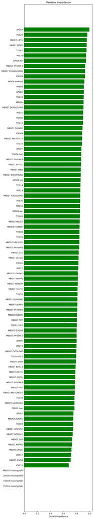

```python
VarImp(dl_v1)
```

```python
pred = dl_v1.predict(test_hex)
test_scores = test_hex['loan_default'].cbind(predictions).as_data_frame()
test_scores.head()
```

```
deeplearning prediction progress: |██████████████████████████████████████████████| (done) 100%
```

|  | loan_default | predict |
| --- | --- | --- |
| 0 | 0 | 0.169949 |
| 1 | 0 | 0.072028 |
| 2 | 0 | 0.140922 |
| 3 | 0 | 0.143368 |
| 4 | 0 | 0.343256 |

```python
createGains(dl_v1)
```

```
deeplearning prediction progress: |██████████████████████████████████████████████| (done) 100%
```

| decile | count | actual | non_actual | cum_count | cum_actual | cum_non_actual | percent_cum_actual | percent_cum_non_actual | if_random | lift | K_S | gain |
| --- | --- | --- | --- | --- | --- | --- | --- | --- | --- | --- | --- | --- |
| 0 | 240 | 83 | 157 | 240 | 83 | 157 | 0.17 | 0.08 | 49.0 | 1.69 | 9.0 | 34.58 |
| 1 | 240 | 62 | 178 | 480 | 145 | 335 | 0.30 | 0.18 | 98.0 | 1.48 | 12.0 | 30.21 |
| 2 | 240 | 63 | 177 | 720 | 208 | 512 | 0.42 | 0.27 | 147.0 | 1.41 | 15.0 | 28.89 |
| 3 | 240 | 58 | 182 | 960 | 266 | 694 | 0.54 | 0.36 | 196.0 | 1.36 | 18.0 | 27.71 |
| 4 | 240 | 53 | 187 | 1200 | 319 | 881 | 0.65 | 0.46 | 245.0 | 1.30 | 19.0 | 26.58 |
| 5 | 240 | 56 | 184 | 1440 | 375 | 1065 | 0.77 | 0.56 | 294.0 | 1.28 | 21.0 | 26.04 |
| 6 | 240 | 35 | 205 | 1680 | 410 | 1270 | 0.84 | 0.66 | 343.0 | 1.20 | 18.0 | 24.40 |
| 7 | 240 | 35 | 205 | 1920 | 445 | 1475 | 0.91 | 0.77 | 392.0 | 1.14 | 14.0 | 23.18 |
| 8 | 240 | 28 | 212 | 2160 | 473 | 1687 | 0.97 | 0.88 | 441.0 | 1.07 | 9.0 | 21.90 |
| 9 | 240 | 17 | 223 | 2400 | 490 | 1910 | 1.00 | 1.00 | 490.0 | 1.00 | 0.0 | 20.42 |

```
deeplearning prediction progress: |██████████████████████████████████████████████| (done) 100%

   * ROC curve: The ROC curve plots the true positive rate vs. the false rositive sate

	  * The area under the curve (AUC): A value between 0.5 (random) and 1.0 (perfect), measuring the prediction accuracy

   * Recall (R) = The number of true positives / (the number of true positives + the number of false negatives)
```

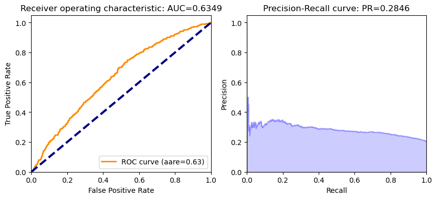

```python
ROC_AUC(dl_v1,test_hex,'loan_default')
```

Conclusion:

- This is the first attempt of modeling with training sample
- The model's ROC curve has AUC score of 0.63.

The next step is to grid search for optimal hyperparameters